# AE 02: Data Visualization

due Tuesday September 5 at 5:45pm

Author

SOLUTIONS

## Goals

In this application exercise, you will…

- learn how to effectively visualize numeric and categorical data.
- continue developing a workflow for reproducible data analysis.

## Getting started

Hit **Render** to begin. You may need to change the Settings (Gear & Sprocket icon) to “Preview in Viewer Pane” to view the html file in the Viewer pane.

# Packages

We will use the **tidyverse** and **viridis** packages to create and customize plots in R.

# Data: Let’s take a trip to the Midwest

The data in this lab is in the `midwest` data frame. It is part of the **ggplot2** R package, so the `midwest` data set is automatically loaded when you load the tidyverse package.

The data contains demographic characteristics of counties in the Midwest region of the United States.

Because the data set is part of the **ggplot2** package, you can read documentation for the data set, including variable definitions by typing `?midwest` in the **console**.

# Exercises

As we’ve discussed in lecture, your plots should include an informative title, axes should be labeled, and careful consideration should be given to aesthetic choices.

Remember that continuing to develop a sound workflow for reproducible data analysis is important as you complete all assignments in this course. Paying attention to how this .qmd is organized and formatted will help you learn best practices for creating your own reports. That is, pay attention to how code chunks are labeled, how headers and sub-headers and font changes are used, and how spacing and line breaks are used in the code.

Also keep in mind that you’re not just practicing your technical coding skills, but you’re also developing your investigative skills as a data scientist - **be curious about the data** and **dig further** into it when your visualizations reveal certain patterns or unusual observations.

## Exercise 1

Make a histogram to visualize the population density of counties. Set the number of bins to 10 and include axes labels and a title.

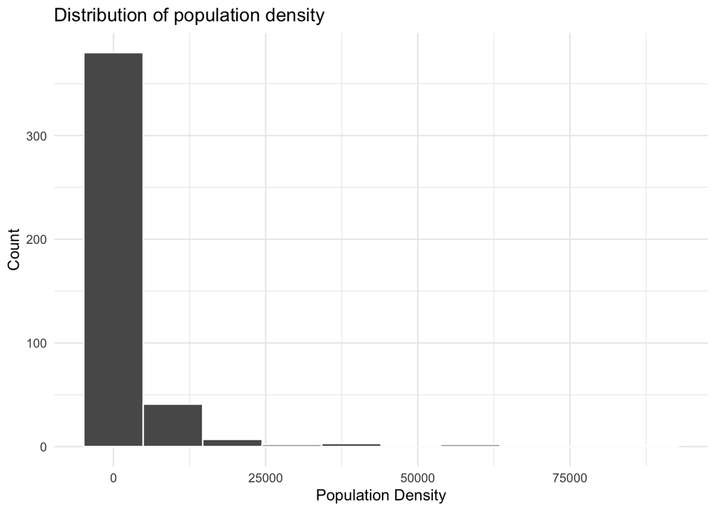

```r
ggplot(midwest, aes(x = popdensity)) +
  geom_histogram(bins = 10, color = "white") +
  theme_minimal() +
  labs(x = "Population Density",
       y = "Count",
       title = "Distribution of population density")
```

> The distribution is unimodal and right-skewed. There appears to be one outlier around 80,000. A closer inspection of the data indicates that this is Cook County, IL, where Chicago is located.

## Exercise 2

Create a scatterplot of the percentage of people with a college degree (`percollege`) versus percentage below poverty (`percbelowpoverty`) with points colored by `state`. Label the axes and legend and give the plot a title. Use the `scale_color_viridis` function to apply the viridis color palette to your plot.

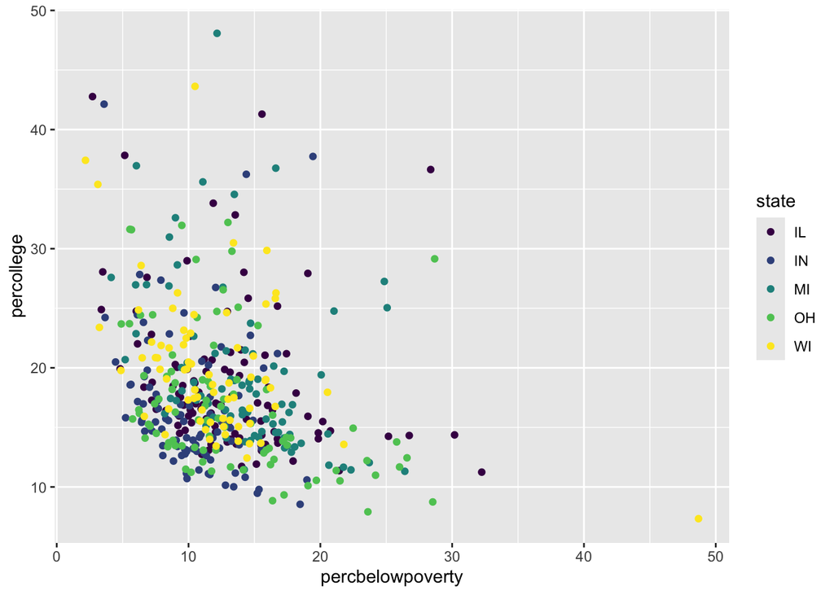

```r
ggplot(midwest, aes(x = percbelowpoverty,
                    y = percollege, color = state)) +
  geom_point() +
  scale_color_viridis_d()
```

## Exercise 3

Now, let’s examine the relationship between the same two variables, using a separate plot for each state.

- Label the axes and give the plot a title.
- Add a layer called `geom_smooth` with the argument `se = FALSE` to add a smooth curve fit to the data.
- Which plot do you prefer - this plot or the plot in Ex 2?

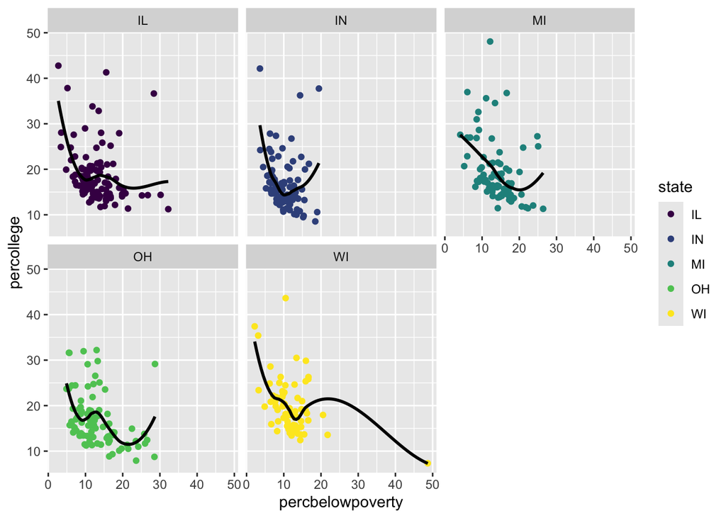

```r
ggplot(midwest, aes(x = percbelowpoverty,
                    y = percollege, color = state)) +
  facet_wrap(~state) +
  geom_point() +
  geom_smooth(se = FALSE, color = "black") +
  scale_color_viridis_d()
```

> This plot makes it easier to discern patterns by state and verify that the negative trend is generally true for each state.

## Exercise 4

*Do some states have counties that tend to be geographically larger than others?* To explore this question, create side-by-side boxplots of area (`area`) of a county based on state (`state`).

- Describe what you observe from the plot.
- Which state has the single largest county? How do you know based on the plot?

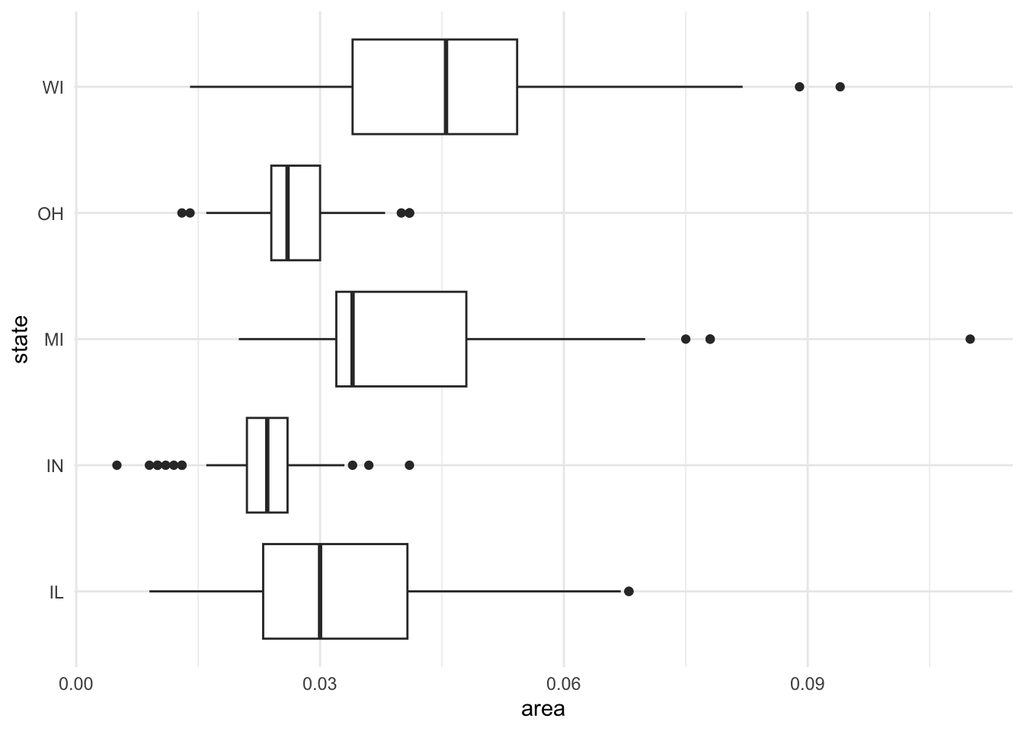

```r
ggplot(midwest, aes(x = area, y = state)) +
  geom_boxplot() +
  theme_minimal()
```

> > Yes, Wisconsin tends to have counties with larger geographic areas, whereas Indiana has smaller counties. Michigan has the county with the largest geographic area.

## Exercise 5

*Do some states have a higher percentage of their counties located in a metropolitan area?*

Create a segmented bar chart with one bar per state and the fill determined by the distribution of `metro`, whether a county is considered in a metro area. The y axis of the segmented barplot should range from 0 to 1.

- What do you notice from the plot?

Note: For this exercise, you should begin with the data wrangling code below. We will learn more about data wrangling code next week.

```r
midwest <- midwest |>
  mutate(metro = ifelse(inmetro == 1, "Yes", "No"))
```

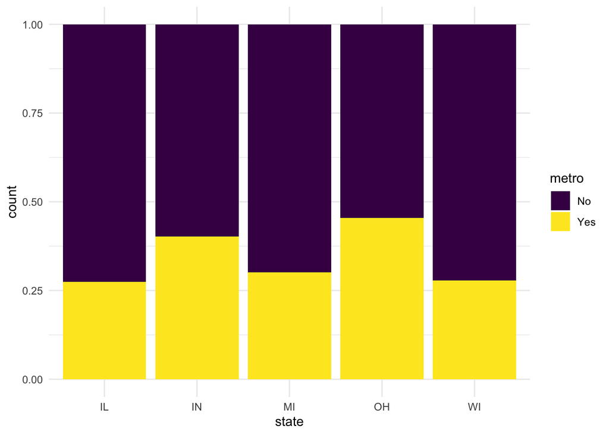

```r
ggplot(midwest, aes(x = state, fill = metro)) +
  geom_bar(position = "fill") +
  scale_fill_viridis_d() +
  theme_minimal()
```

## Exercise 6

What are two more questions you could investigate using this data? For each, state the question and produce a visualization to investigate it.

> *Is poverty more common inside or outside of metro areas?*

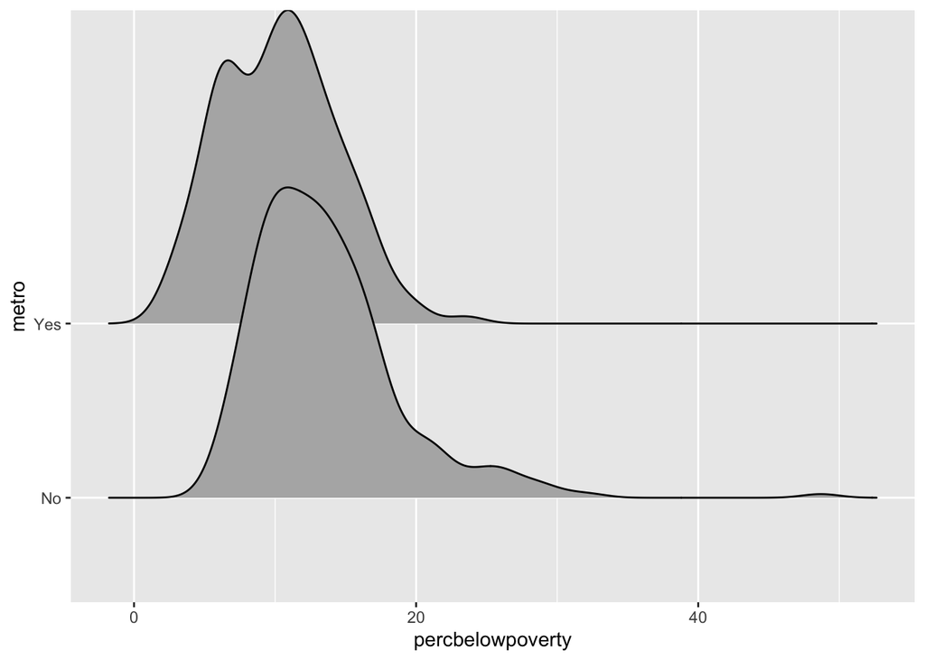

```r
ggplot(midwest, aes(x = percbelowpoverty, y = metro)) +
  geom_density_ridges()
```

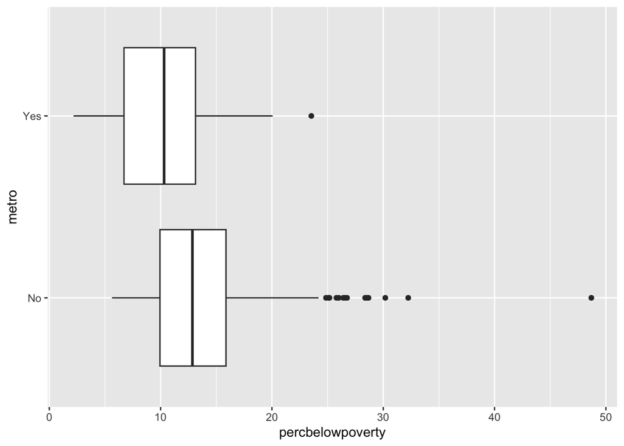

```r
ggplot(midwest, aes(x = percbelowpoverty, y = metro)) +
  geom_boxplot()
```

> *What is the relationship between % living in poverty and % white?*

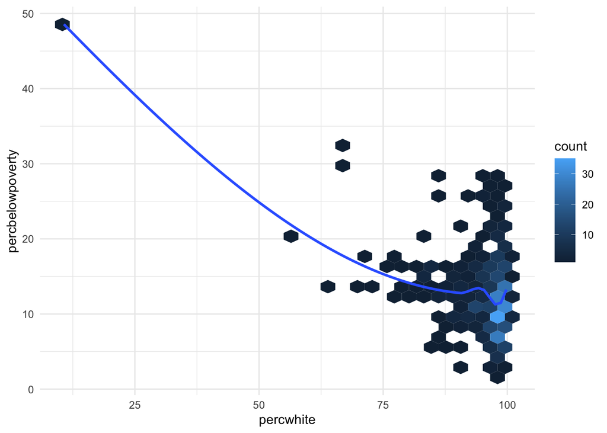

```r
ggplot(midwest, aes(x = percwhite, y = percbelowpoverty)) +
  geom_hex() +
  geom_smooth(se = FALSE) +
  theme_minimal()
```

## BONUS

Recreate the plot below. (Hints: [The `ggplot2` reference page](https://ggplot2.tidyverse.org/reference/ggtheme.html) will be helpful in determining the theme. The `size` of the points is 0.75.)

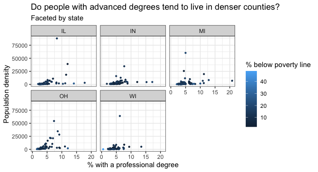

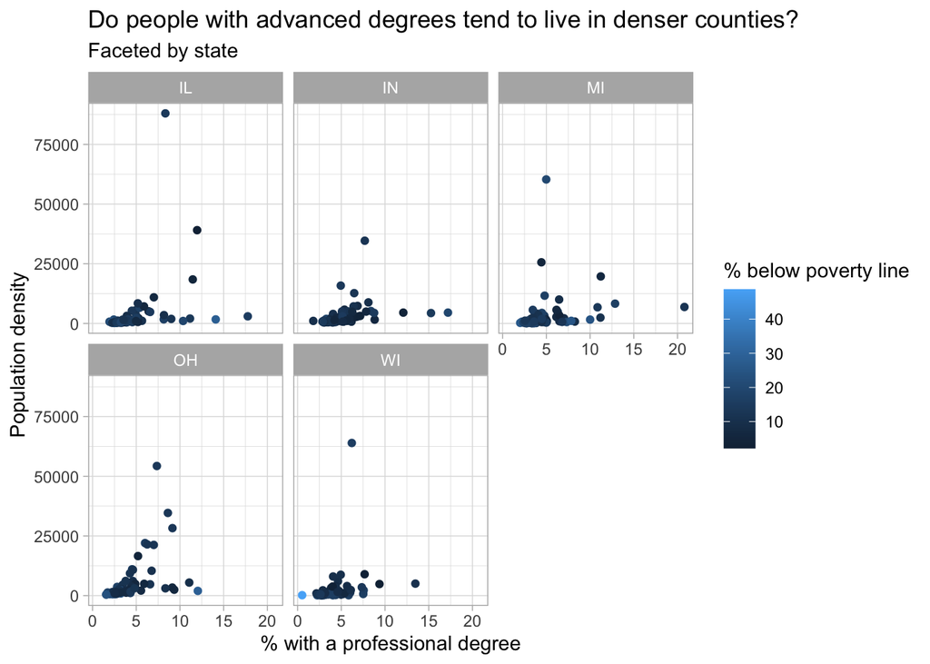

```r
ggplot(midwest, aes(x = percprof, y = popdensity,
                    color = percbelowpoverty)) +
  geom_point() +
  facet_wrap(~state) +
  theme_light() +
  labs(x = "% with a professional degree",
       y = "Population density",
       title = "Do people with advanced degrees tend to live in denser counties?",
       subtitle = "Faceted by state",
       color = "% below poverty line")
```

# Submission

Before submitting, open up your .html in a full window and inspect the following:

- Check your code for neatness - add spaces and line breaks where appropriate to improve readability
- Check your visualizations for informative and clean labels and titles
- Check that you’ve interpreted each visualization
- Make sure extraneous warnings and messages are suppressed (e.g. set `warning = FALSE, message = FALSE)`
- Check that your text responses are visually distinguished
- Check for overall neatness & organization of the report (e.g. headers, subheaders, use of bullets, font changes)

To submit, upload your .html document to the relevant assignment on Brightspace. Refer back to [Lab 01](https://kgfitzgerald.github.io/NOVA_STAT_4380/labs/lab-01-hello-r.html) for detailed instructions on how to export and submit your assignment.

# Grading (10 pts)

Application exercises are graded on completion. You will receive full credit if you turn in the .html on time and a reasonable attempt was made on each exercise.